# presentacion_clase_04 slides

[figure not shown]

DATA SCIENCE

MÓDULO 1

Estadística Descriptiva

### Objetivos de la Clase

- Repasar las medidas de tendencia central (media, mediana y moda)
- Repasar cómo la media, mediana y moda son afectadas por la asimetría
- Estudiar las medidas de correlación y covarianza.

Introducción

[figure not shown]

### Introducción: Revisión de Estadística

Estadística descriptiva: describir, sumarizar y comprender los datos.

Medidas de Tendencia Central: proveer información descriptiva sobre el valor numérico que es considerado el más usual para una variable cuantitativa:

- Media
- Mediana
- Moda

Asimetría en la distribución de datos: efecto en la media, mediana y moda.

Medidas de Variabilidad:

- Rango
- Varianza
- Desvío Estándar
- Coeficiente de Variación

Medidas de Tendencia Central

[figure not shown]

### Media

Dados los n números ${\{x_{1},x_{2},\ldots ,x_{n}\}}$ la media aritmética se define como:

\begin{equation} \bar {x} = {\frac {1}{n}} \sum _{i=1}^{n}x_{i} ={\frac {x_{1}+x_{2}+\cdots +x_{n}}{n}} \end{equation}

Por ejemplo, para la muestra 8, 5 y -1, su media es:

\begin{equation} \bar {x} ={\frac {8+5+(-1)}{3} = 4} \end{equation}

```python
import numpy as np
xs = np.array([8, 5, -1])
np.mean(xs)
```

```
4.0
```

### Mediana

La mediana es el valor del "medio" de una lista **ordenada** de datos (o el valor que separa la primera mitad y la segunda mitad de una distribución).

Para una lista ordenada la mediana es calculada de diferente manera dependiendo de la cantidad de elementos de la misma:

**Impar**:

[1, 2, 3, 5, **7**, 8, 9, 10, 15]

9 elementos

La mediana es el valor de la posición 5 (la posición del “medio”)

Mediana = 7

**Par**:

[-5, -1, 0, **1**, **2**, 3, 8, 20]

8 elementos

La mediana es la **media de los valores en las dos posiciones centrales**

Mediana = (1+2)/2 = 1.5

```python
import numpy as np
xs = np.array([8, 5, -1])
np.median(xs)
```

```
5.0
```

### Moda

La moda es el **valor que aparece con mayor frecuencia** o más veces en la distribución.

Por ejemplo, la moda de [0,1,1,2,2,2,2,3,3,4,4,4,5] es 2.

La moda no es necesariamente única. Puede ocurrir que haya dos valores diferentes que sean los más frecuentes.

Por ejemplo, para [10, 13, 13, 20, 20], tanto 13 como 20 son la moda.

Asimetría

[figure not shown]

### Asimetría

[figure not shown]

- Una distribución con asimetría a izquierda, significa que la cola de la izquierda es más larga que la de la derecha (gráfico de la izquierda).
- Una distribución simétrica no presenta este fenómeno dado que sus colas son de igual longitud (gráfico del centro).
- Una distribución con asimetría a derecha significa que la cola del lado derecho es más larga que la del lado izquierdo (gráfico de la derecha)

### Asimetría y las medidas de Tendencia Central

La media, mediana y moda son afectadas por la asimetría

[figure not shown]

### Asimetría a izquierda

### Simetría

### Asimetría a derecha

### Media < Mediana < Moda

### Media = Mediana = Moda

### Moda < Mediana < Media

Medidas de Dispersión

[figure not shown]

### Medidas de Dispersión o Variabilidad

Las medidas de variabilidad indican cómo están esparcidos los datos.

Vamos a presentar:

- Rango
- Varianza
- Desvío estándar
- Coeficiente de variación

Estas medidas proveen información complementaria a las medidas de tendencia central (media, mediana y moda).

### Rango y Rango Intercuartil

Sean ${ x_{1},x_{2},x_{3},\ldots ,x_{n} }$ los datos de una muestra ordenada en orden creciente, el rango es $x_{n} - x_{1}$

El rango intecuartil es la diferencia entre el tercer y el primer cuartil de la distribución.

Acumula el 50% de la distribución y, a diferencia del rango, es un estadístico robusto, es decir que se ve poco afectado por valores extremos.

```python
import numpy as np

xs = np.array([8, 5, -1])

rango = np.max(xs) - np.min(xs)

print(rango)

q3, q1 = np.percentile(xs, [75 ,25])

rango_intercuartil = q3 - q1

print(rango_intercuartil)
```

```
9
4.5
```

### Varianza

La varianza es un valor numérico utilizado para describir cuánto varían los números de una distribución respecto a su media.

Si tenemos un conjunto de valores de una variable, la varianza se calcula de la siguiente forma:

\begin{equation} \sigma_{n}^{2} = \frac{1}{n} \sum _{i=1}^{n} (x_i - \bar{x})^{2} \end{equation}

Siendo:

$x_{i}$: cada dato

$\bar{x}$: media de los datos

$n$: número de datos

Esto es el promedio de **la diferencia elevada al cuadrado entre cada valor y la media**

```python
import numpy as np

xs = np.array([8, 5, -1])

np.var(xs)
```

```
14.0
```

### Desvío Estándar

Es la raíz cuadrada de la varianza

\begin{equation} s_{n} = \sqrt{\frac{1}{n} \sum _{i=1}^{n} (x_i - \bar{x})^{2}} \end{equation}

El desvío estándar es la raíz cuadrada de la varianza

El desvío es una medida de la dispersión de los datos

**NO** es la desviación promedio con respecto de la media. Como los desvíos están elevados al cuadrado los desvíos muy grandes cuentan más que proporcionalmente.

```python
import numpy as np

xs = np.array([8, 5, -1])

np.std(xs)
```

```
3.7416573867739413
```

```python
np.var(xs) == np.std(xs)**2
```

```
True
```

### Varianza y desvío Estándar

Una ventaja del desvío estándar es que **está expresada en las mismas unidades** que se usaron para medir los datos.

(En cambio, la varianza tiene otras unidades ya que está elevada al cuadrado. )

[figure not shown]

### Coeficiente de Variación

Es el desvío estándar dividido por la media

\begin{equation} CV = \frac{s_{n}}{\bar{x}} . 100 \end{equation}

El coeficiente de variación permite **comparar la dispersión de variables diferentes**.

Sirve si las variables tienen medias distintas.

También si las variables están expresadas en unidades distintas.

El coeficiente de variación **no tiene unidades**.

Medidas de asociación entre variables

[figure not shown]

### Medidas de asociación lineal entre variables

- Covarianza
- Correlación

### Covarianza

Decimos que dos variables X e Y, tienen covarianza positiva cuando tienden a encontrarse por encima de su media al mismo tiempo y tienen covarianza negativa cuando al mismo tiempo, tienden a encontrarse una por debajo y otra por encima.

En cambio X e Y tienen **covarianza cercana a cero** cuando las variables pueden encontrarse por encima o por debajo de su media **independientemente** de lo que haga la otra.

**La covarianza mide la asociación lineal entre ambas variables**, es decir, qué tanto se asemeja la relación con una función lineal.

[figure not shown]

### Matriz de Covarianzas

La covarianza se mide como

\begin{equation} cov_{XY} = \frac{1}{n} \sum_{i=1}^{n} {(x_i - \bar{x})(y_i - \bar{y})} \end{equation}

La covarianza de un conjunto de datos con $p$ variables se puede representar con una matriz de $p$ x $p$ llamada **matriz de varianzas y covarianzas**:

- En la diagonal se encuentra la varianza de cada acción
- En el resto de la matriz se encuentran las covarianzas

[figure not shown]

```python
import numpy as np

x = [-2.1, -1,  4.3]

y = [3,  1.1,  0.12]

X = [x, y]

print('X: ')
print(X)

print('-----')
print('Covarianzas: ')
np.cov(X)
```

```
X:
[[-2.1, -1, 4.3], [3, 1.1, 0.12]]
-----
Covarianzas:
```

```
array([[11.71      , -4.286     ],
       [-4.286     ,  2.14413333]])
```

### Correlación

La correlación es una **versión estandarizada** (dividida por los desvíos estándar) de la covarianza

\begin{equation} r_{XY} = \frac{1}{n} \sum_{i=1}^{n} {\frac{(x_i - \bar{x})}{s_x}\frac{(y_i - \bar{y})}{s_y}} \end{equation}

- La correlación está acotada entre 1 y -1.
- Siempre que la covarianza es positiva, la correlación es positiva y viceversa.
- La correlación no tiene unidades físicas, y la covarianza sí.

[figure not shown]

```python
import numpy as np

x = [-2.1, -1,  4.3]

y = [3,  1.1,  0.12]

X = [x, y]

print('X: ')
print(X)

print('-----')
print('Correlación: ')
np.corrcoef(X)
```

```
X:
[[-2.1, -1, 4.3], [3, 1.1, 0.12]]
-----
Correlación:
```

```
array([[ 1.        , -0.85535781],
       [-0.85535781,  1.        ]])
```

Hands-on

[figure not shown]

### Ejercicio 1

Leer en un NumPy array los datos del archivo sales_data_sample_excercise.csv que encuentran en la carpeta Data de esta clase.

Este archivo tiene algunos datos numéricos y otros de tipo cadena de caracteres.

Las columnas son:

- ORDERNUMBER: int, id de la orden
- SALES: float, monto abonado
- MONTH_ID: int, mes
- YEAR_ID: int, año
- PRODUCTLINE: str, producto
- COUNTRY: str, país de venta

### Ejercicio 2

Calcular la media y mediana de la columna SALES. ¿Qué podemos decir sobre la simetría en la distribución de estos valores?

### Ejercicio 3

Usando esta función

`import seaborn as sns`

Graficar los valores de la columna SALES para USA y Japan por separado para el año 2004.

¿Qué podemos decir sobre la distribución de ventas en esos dos países durante ese año?

### Ejercicio 4

Teniendo en cuenta la distribución de datos en la columna SALES en USA y en Japan durante el 2004 ¿qué medidas de dispersión calcularía? ¿Por qué?

Calcular las medidas elegidas. ¿Qué podemos decir sobre la dispersión en las ventas en esos dos países durante ese año?

### Solucion

### Ejercicio 1

```python
import numpy as np
```

```python
data_location = '../Data/sales_data_sample_excercise.csv'
data = np.genfromtxt(data_location, skip_header=1, delimiter='\t', dtype= str)
data
```

```
array([['10107', '2871', '2', '2003', 'Motorcycles', 'USA'],
       ['10121', '2765.9', '5', '2003', 'Motorcycles', 'France'],
       ['10134', '3884.34', '7', '2003', 'Motorcycles', 'France'],
       ...,
       ['10386', '5417.57', '3', '2005', 'Ships', 'Spain'],
       ['10397', '2116.16', '3', '2005', 'Ships', 'France'],
       ['10414', '3079.44', '5', '2005', 'Ships', 'USA']], dtype='<U16')
```

```python
sales = data[:, 1]
sales
```

```
array(['2871', '2765.9', '3884.34', ..., '5417.57', '2116.16', '3079.44'],
      dtype='<U16')
```

```python
sales_numeric = sales.astype(np.float)
sales_numeric
```

```
array([2871.  , 2765.9 , 3884.34, ..., 5417.57, 2116.16, 3079.44])
```

### Ejercicio 2

```python
media = np.mean(sales_numeric)
media
```

```
3553.889071909316
```

```python
mediana = np.median(sales_numeric)
mediana
```

```
3184.8
```

La mediana es menor que la media, entonces la distribución es asimétrica a derecha

### Ejercicio 3

```python
import seaborn as sns

def distribution_plotter(data, label):
    sns.set(rc={"figure.figsize": (7, 5)})
    sns.set_style("white")
    dist = sns.histplot(data, stat = 'count', kde = False,
                        line_kws = {'linewidth':5},
                        binwidth = 500)
    dist.set_title('Distribucion ' + label + '\n', fontsize = 16)
```

```python
data_anno = data[:, 3]
data_anno
```

```
array(['2003', '2003', '2003', ..., '2005', '2005', '2005'], dtype='<U16')
```

```python
data_pais = data[:, 5]
data_pais
```

```
array(['USA', 'France', 'France', ..., 'Spain', 'France', 'USA'],
      dtype='<U16')
```

```python
mask_2004 = data_anno == '2004'
mask_japan = data_pais == 'Japan'
mask_usa = data_pais == 'USA'

mask_2004_japan = np.logical_and(mask_2004, mask_japan)
mask_2004_usa = np.logical_and(mask_2004, mask_usa)

sales_2004_japan = sales[mask_2004_japan]
sales_2004_japan_numeric = sales_2004_japan.astype(np.float)

sales_2004_usa = sales[mask_2004_usa]
sales_2004_usa_numeric = sales_2004_usa.astype(np.float)
```

```python
sales_2004_japan_numeric.shape
```

```
(42,)
```

```python
sales_2004_usa_numeric.shape
```

```
(474,)
```

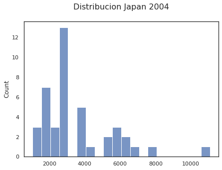

```python
distribution_plotter(sales_2004_japan_numeric, 'Japan 2004')
```

```python
np.mean(sales_2004_japan_numeric)
```

```
3557.6778571428563
```

```python
np.median(sales_2004_japan_numeric)
```

```
2865.505
```

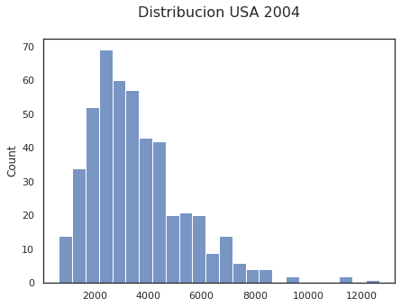

```python
distribution_plotter(sales_2004_usa_numeric, 'USA 2004')
```

```python
np.mean(sales_2004_usa_numeric)
```

```
3555.8453375527424
```

```python
np.median(sales_2004_usa_numeric)
```

```
3182.25
```

### Ejercicio 4

Podemos usar el desvío estándar o la distancia intercuartil para comprarar la dispersión en las ventas de USA y Japan durante el 2004

```python
std_usa = np.std(sales_2004_usa_numeric)
mean_usa = np.mean(sales_2004_usa_numeric)
mean_usa, std_usa
```

```
(3555.8453375527424, 1792.1729633074253)
```

```python
q75_usa, q25_usa = np.percentile(sales_2004_usa_numeric, [75 ,25])
iqr_usa = q75_usa - q25_usa
iqr_usa
```

```
2121.1949999999997
```

```python
std_japan = np.std(sales_2004_japan_numeric)
mean_japan = np.mean(sales_2004_japan_numeric)
mean_japan, std_japan
```

```
(3557.6778571428563, 1972.7224632333377)
```

```python
q75_japan, q25_japan = np.percentile(sales_2004_japan_numeric, [75 ,25])
iqr_japan = q75_japan - q25_japan
iqr_japan
```

```
1965.0299999999993
```

```python
cv_usa = std_usa / mean_usa
cv_usa
```

```
0.5040075687152529
```

```python
cv_japan = std_japan / mean_japan
cv_japan
```

```
0.5544972148820737
```